# Vaccine allocation project results

GMB

2022-06-01

# 1 Introduction

This document brings together results from multiple model runs. It is intended to be re-run as the model is updated.

NOTE: The setting for this run is: SLE

**Focus questions:**

- What impact will the existing vaccination plan have on morbidity and mortality?
- What impact can be achieved under different levels of vaccine coverage?
- What are the potential benefits of expanding the immunisation schedule to include children?

**Overarching assumptions**

Unless otherwise specified, key model parameters in this run are:

| Variable | Value | Source |
| --- | --- | --- |
| Circulating strain | omicron |  |
| Length of model run | 52 |  |
| Current vaccine coverage | dose one: 26%; dose two: 18% | John Hopkins COVID-19 vaccination data |
| Current vaccine coverage target | 51.6% | Government target in COVAX documentation May 2021 |
| Proportion of population willing to be vaccinated | 88% | Survey estimating vaccine acceptance in January 2021 (Solis et al., 2021) |
| Daily capacity for vaccination (doses) | 11075 | Slightly lower than the pilot vaccination campaign October-November 2021 |
| Anticipated type of future vaccine doses | Johnson & Johnson | The Government of Sierra Leone has demonstrated a strong preference for this vaccine, negotiating with major donors, such as the Government of Italy, to change their donations of double-dose vaccines … |
| Waning of VE against acquisition | TRUE |  |
| Waning of VE against severe disease | FALSE |  |
| Waning of infection-derived immunity against acquisition | TRUE |  |
| Waning of infection-derived immunity against severe outcomes | Not yet included |  |

**Other assumptions/limitations:**

- Linear roll-out of vaccines (Lowy Institute report and trends in the ACT do not support this)
- Vaccine effectiveness estimates last updated on the 14th of April 2022 from WHO live systematic review (https://view-hub.org/covid-19/effectiveness-studies)

**Next steps for noting:**

- update of infection- and vaccine-derived immunity
- sensitivity analysis
  - turning on/off waning of vaccine-derived immunity
  - simulating outbreaks of different strains
  - experimenting with different age-prioritisation strategies
  - other?

# 2 Impact of current program targets

Roll out of current program target (51.6% coverage) during or prior to an outbreak:

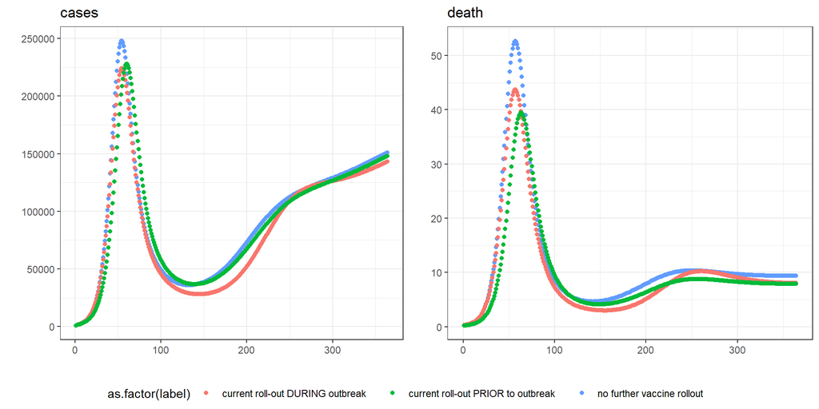

Absolute difference in outcomes (compared to no further vaccine roll-out)

| scenario | death | hosp | severe_disease | YLL | cases |
| --- | --- | --- | --- | --- | --- |
| current roll-out DURING outbreak | 646 | 24,176 | 7,802 | 6,851 | 2,878,902 |
| current roll-out PRIOR to outbreak | 760 | 30,033 | 9,741 | 8,314 | 1,043,675 |

Relative difference in outcomes

| scenario | death | hosp | severe_disease | YLL | cases |
| --- | --- | --- | --- | --- | --- |
| current roll-out DURING outbreak | 15.42 | 9.92 | 14.32 | 12.93 | 8.46 |
| current roll-out PRIOR to outbreak | 18.12 | 12.32 | 17.88 | 15.69 | 3.07 |

# 3 Varying levels of coverage

## 3.1 Using current age-specific eligiblity

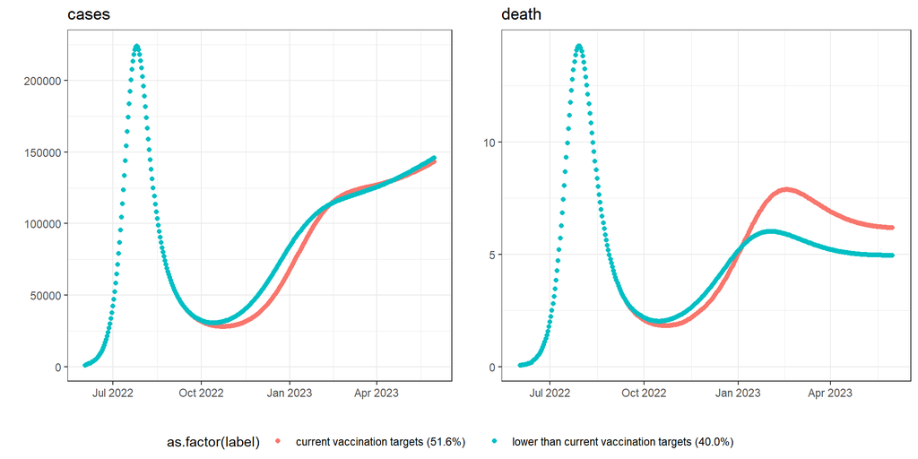

Absolute difference in outcomes (compared to current vaccine targets)

| scenario | death | hosp | severe_disease | YLL | cases |
| --- | --- | --- | --- | --- | --- |
| lower than current vaccination targets (40.0%) | 180 | 6,809 | 2,286 | 1,936 | -1,168,989 |

Relative difference in outcomes (%)

| scenario | death | hosp | severe_disease | YLL | cases |
| --- | --- | --- | --- | --- | --- |
| lower than current vaccination targets (40.0%) | 9.4 | 8.98 | 9.01 | 9.32 | -3.75 |

## 3.2 Expanding eligibility to children (DURING an outbreak)

### 3.2.1 Run current vaccine campaign, then expand to children

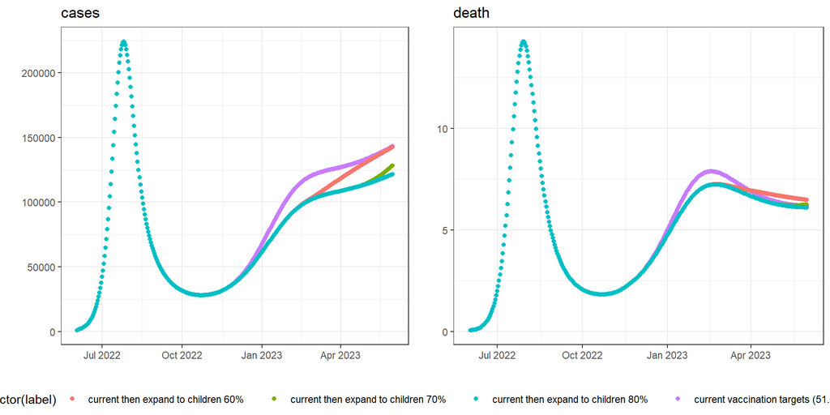

Absolute difference in outcomes (compared to current vaccine targets)

| scenario | death | hosp | severe_disease | YLL | cases |
| --- | --- | --- | --- | --- | --- |
| current then expand to children 60% | 27 | -2,430 | 228 | -34 | 1,507,678 |
| current then expand to children 70% | 54 | -2,050 | 478 | 174 | 2,577,682 |
| current then expand to children 80% | 56 | -1,877 | 496 | 202 | 2,673,391 |

Relative difference in outcomes (%)

| scenario | death | hosp | severe_disease | YLL | cases |
| --- | --- | --- | --- | --- | --- |
| current then expand to children 60% | 1.41 | -3.20 | 0.90 | -0.16 | 4.84 |
| current then expand to children 70% | 2.80 | -2.70 | 1.88 | 0.84 | 8.28 |
| current then expand to children 80% | 2.90 | -2.47 | 1.96 | 0.97 | 8.59 |

### 3.2.2 Expand to children now

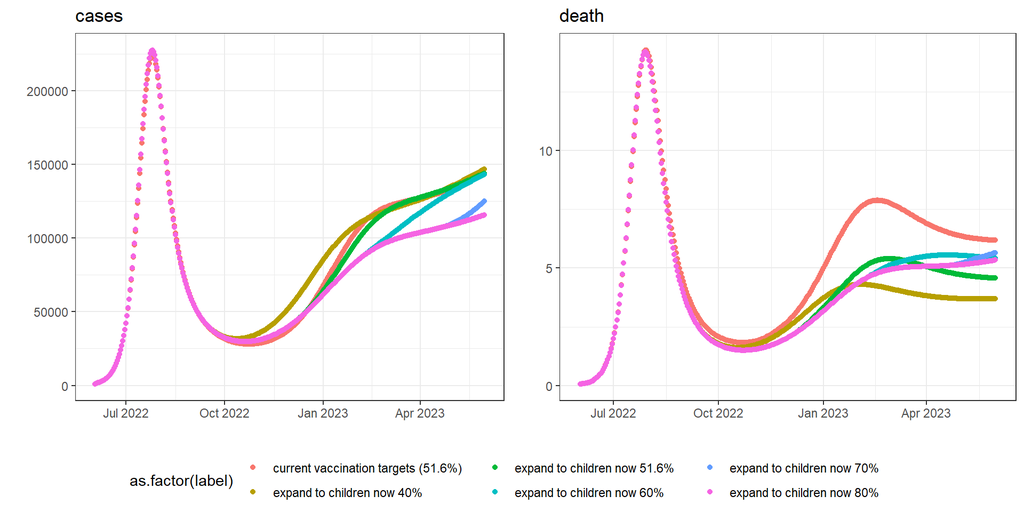

Absolute difference in outcomes (compared to current vaccine targets)

| scenario | death | hosp | severe_disease | YLL | cases |
| --- | --- | --- | --- | --- | --- |
| expand to children now 40% | 498 | 14,066 | 6,309 | 4,944 | -1,431,448 |
| expand to children now 51.6% | 393 | 7,604 | 4,975 | 3,607 | 130,369 |
| expand to children now 60% | 369 | 5,440 | 4,594 | 3,220 | 1,559,238 |
| expand to children now 70% | 395 | 6,000 | 4,827 | 3,439 | 3,012,715 |
| expand to children now 80% | 401 | 6,298 | 4,898 | 3,509 | 3,149,976 |

Relative difference in outcomes (%)

| scenario | death | hosp | severe_disease | YLL | cases |
| --- | --- | --- | --- | --- | --- |
| expand to children now 40% | 25.99 | 18.54 | 24.88 | 23.82 | -4.60 |
| expand to children now 51.6% | 20.54 | 10.02 | 19.62 | 17.37 | 0.42 |
| expand to children now 60% | 19.26 | 7.17 | 18.12 | 15.51 | 5.01 |
| expand to children now 70% | 20.64 | 7.91 | 19.03 | 16.56 | 9.68 |
| expand to children now 80% | 20.96 | 8.30 | 19.31 | 16.90 | 10.12 |

## 3.3 Expanding eligibility to children (PRIOR TO an outbreak)

Note: If waning immunity against severe outcomes ON, this looks like a bad idea.

### 3.3.1 Run current vaccine campaign, then expand to children

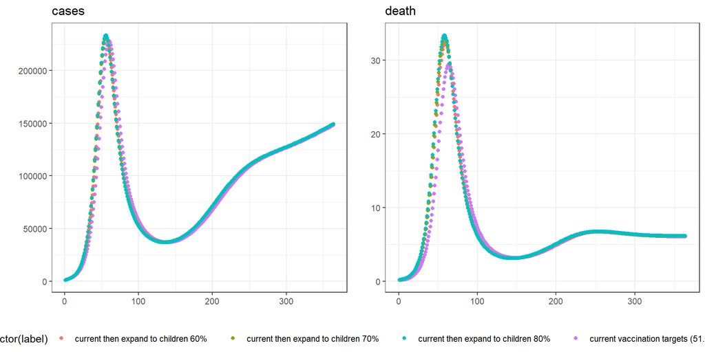

Absolute difference in outcomes (compared to current vaccine targets)

| scenario | death | hosp | severe_disease | YLL | cases |
| --- | --- | --- | --- | --- | --- |
| current then expand to children 60% | -94 | -17,164 | -1,106 | -2,140 | -423,031 |
| current then expand to children 70% | -125 | -30,163 | -1,441 | -3,456 | -503,387 |
| current then expand to children 80% | -138 | -37,204 | -1,577 | -4,140 | -510,852 |

Relative difference in outcomes (%)

| scenario | death | hosp | severe_disease | YLL | cases |
| --- | --- | --- | --- | --- | --- |
| current then expand to children 60% | -3.62 | -16.51 | -3.20 | -7.52 | -1.28 |
| current then expand to children 70% | -4.81 | -29.01 | -4.17 | -12.15 | -1.53 |
| current then expand to children 80% | -5.32 | -35.79 | -4.56 | -14.55 | -1.55 |

### 3.3.2 Expand to children now

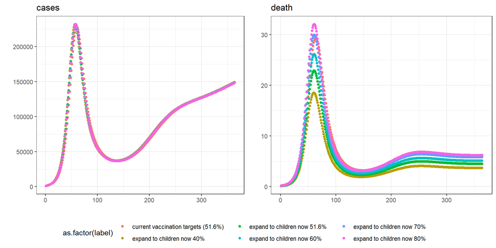

Absolute difference in outcomes (compared to current vaccine targets)

| scenario | death | hosp | severe_disease | YLL | cases |
| --- | --- | --- | --- | --- | --- |
| expand to children now 40% | 1,013 | 31,432 | 13,241 | 10,401 | -435,933 |
| expand to children now 51.6% | 651 | 9,481 | 8,571 | 5,795 | -299,157 |
| expand to children now 60% | 387 | -6,531 | 5,165 | 2,435 | -259,564 |
| expand to children now 70% | 72 | -25,615 | 1,106 | -1,570 | -229,048 |
| expand to children now 80% | -101 | -36,068 | -1,118 | -3,764 | -212,963 |

Relative difference in outcomes (%)

| scenario | death | hosp | severe_disease | YLL | cases |
| --- | --- | --- | --- | --- | --- |
| expand to children now 40% | 38.92 | 30.23 | 38.29 | 36.56 | -1.32 |
| expand to children now 51.6% | 25.01 | 9.12 | 24.78 | 20.37 | -0.91 |
| expand to children now 60% | 14.86 | -6.28 | 14.94 | 8.56 | -0.79 |
| expand to children now 70% | 2.75 | -24.64 | 3.20 | -5.52 | -0.69 |
| expand to children now 80% | -3.87 | -34.69 | -3.23 | -13.23 | -0.65 |

# 4 Varying speed of vaccine roll-out

This section models varying speeds of vaccine roll-out *DURING* an outbreak.

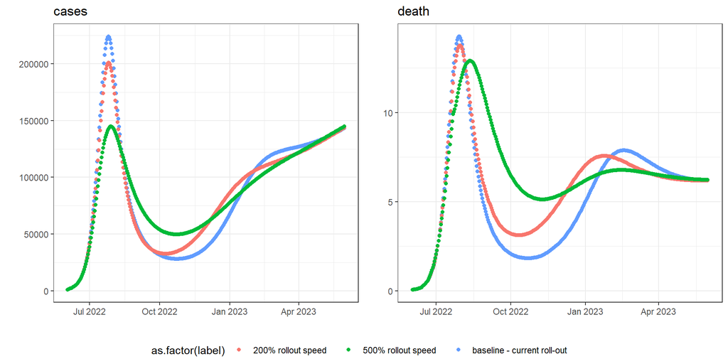

Absolute difference in outcomes (compared to current rollout speed)

| scenario | death | hosp | severe_disease | YLL | cases |
| --- | --- | --- | --- | --- | --- |
| 200% rollout speed | -203 | -7,856 | -2,636 | -2,217 | -429,843 |
| 500% rollout speed | -440 | -18,538 | -6,048 | -5,000 | -483,451 |

Relative difference in outcomes (%)

| scenario | death | hosp | severe_disease | YLL | cases |
| --- | --- | --- | --- | --- | --- |
| 200% rollout speed | -10.62 | -10.36 | -10.40 | -10.68 | -1.38 |
| 500% rollout speed | -22.99 | -24.44 | -23.85 | -24.08 | -1.55 |

# 5 Sensitivity analysis (see FleetDeputy output)

# 6 Appendix - parameter estimates

**Vaccine effectiveness estimates**

**Point estimates by type, dose and outcome**

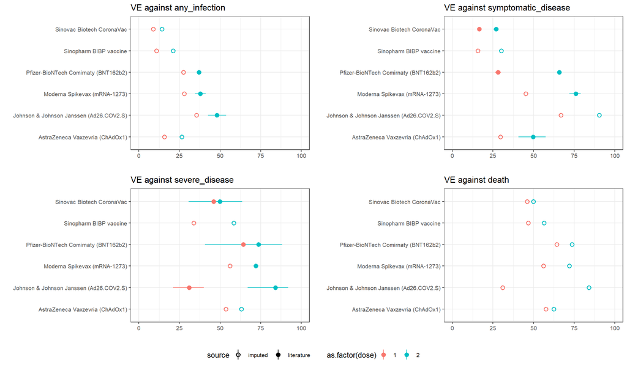

```
## list()
## attr(,"class")
## [1] "waiver"
```

**Infection-derived immunity estimate**

Rho severe outcomes: 0.88

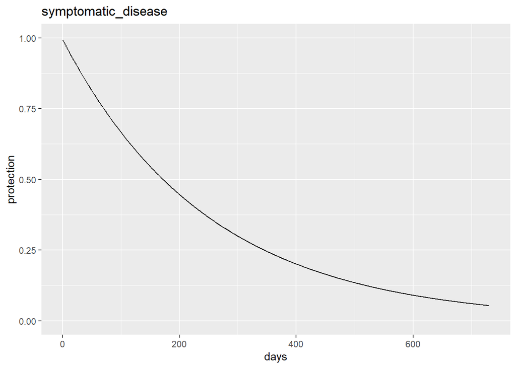

**Seroprevalence**

| age_group | seroprev |
| --- | --- |
| 0 to 4 | 7.643630 |
| 5 to 17 | 10.040014 |
| 18 to 29 | 6.607331 |
| 30 to 44 | 9.297261 |
| 45 to 59 | 19.783513 |
| 60 to 69 | 16.186511 |
| 70 to 100 | 16.186511 |

**Other key parameters**

| Variable | Value | Source |
| --- | --- | --- |
| Seed of outbreak (initially infected) | 8306.442 individuals |  |
| Delay from first dose to protection | 21 days |  |
| Delay from second dose to protection | 14 days |  |